# Public Submissions By Year

This is a quick example on generating plots of the publicly available *Staphylococcus aureus* sequencing data by year.

### Import Packages

```r
library(staphopia)
library(ggplot2)
library(reshape2)
```

### Get Our Data

We’ll use the **get_submission_by_year()** function to do exactly that, retrieve submission counts by year.

```r
results <- get_submission_by_year()
results
```

|  | year | published | unpublished | count | overall_published | overall_unpublished | overall |
| --- | --- | --- | --- | --- | --- | --- | --- |
| 1 | 2010 | 169 | 159 | 328 | 169 | 159 | 328 |
| 2 | 2011 | 830 | 790 | 1620 | 999 | 949 | 1948 |
| 3 | 2012 | 3195 | 2464 | 5659 | 4194 | 3413 | 7607 |
| 4 | 2013 | 1976 | 3918 | 5894 | 6170 | 7331 | 13501 |
| 5 | 2014 | 2534 | 7264 | 9798 | 8704 | 14595 | 23299 |
| 6 | 2015 | 1930 | 6588 | 8518 | 10634 | 21183 | 31817 |
| 7 | 2016 | 1543 | 3438 | 4981 | 12177 | 24621 | 36798 |
| 8 | 2017 | 17 | 7157 | 7174 | 12194 | 31778 | 43972 |

In the table above, there are seven columns:

1. year: The year in which an experiment was made public in ENA/SRA
2. published: The number of submissions associated with a publication for a given year
3. unpublished: The number of submissions **not** associated with a publication for a given year
4. count: The number of submissions for a given year
5. overall_published:The sum of published samples of the previous years
6. overall_unpublished: The sum of unpublished samples of the previous years
7. overall: The sum of each of the previous years

### Plotting Our Data

#### Submissions Per Year

Here we are just going to look at the per year submissions.

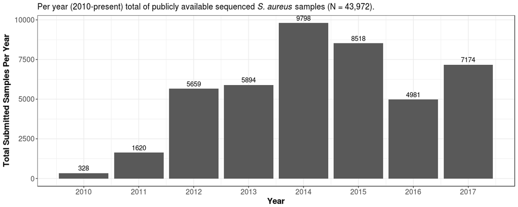

```r
title <- substitute(paste("Per year (2010-present) total of publicly available sequenced ", italic('S. aureus')," samples (N = ", x,")."), list(x=format(max(results$overall), big.mark=',', scientific=FALSE)))
p <- ggplot(data=results, aes(x=year, y=count)) +
    xlab("Year") +
    ylab("Total Submitted Samples Per Year") +
    ggtitle(title) +
    geom_bar(stat='identity') +
    geom_text(aes(label=count), vjust = -0.5) +
    scale_x_continuous(breaks = round(seq(min(results$year), max(results$year), by = 1),1)) +
    theme_bw() +
    theme(axis.text=element_text(size=12),
          axis.title=element_text(size=14,face="bold"))
p
```

#### Overall Submissions

Changing gears a litte, here we are going to look at the overall growth of *S. aureus* sequencing data over the years.

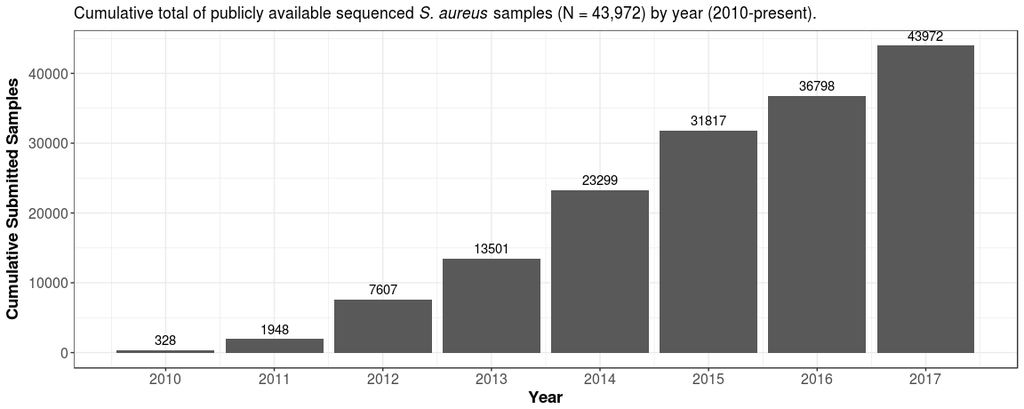

```r
title <- substitute(paste("Cumulative total of publicly available sequenced ", italic('S. aureus')," samples (N = ", x,") by year (2010-present)."), list(x=format(max(results$overall), big.mark=',', scientific=FALSE)))
p <- ggplot(data=results, aes(x=year, y=overall)) +
    xlab("Year") +
    ylab("Cumulative Submitted Samples") +
    ggtitle(title) +
    geom_bar(stat='identity') +
    geom_text(aes(label=overall), vjust = -0.5) +
    scale_x_continuous(breaks = round(seq(min(results$year), max(results$year), by = 1),1)) +
    theme_bw() +
    theme(axis.text=element_text(size=12),
          axis.title=element_text(size=14,face="bold"))
p
```

#### Published vs Unpublished By Year

For our final plot, we’ll look at the number of samples that were referenced in a publication along side those that weren’t. We’ll need to melt the data in order to plot our groups.

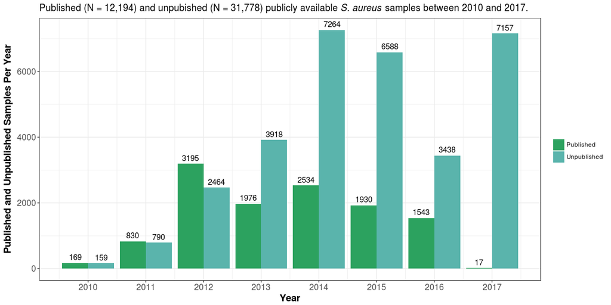

```r
melted <- melt(results, id=c('year'), measure.vars = c('published', 'unpublished'))
melted$title <- ifelse(melted$variable == 'published', 'Published', 'Unpublished')
title <- substitute(paste("Published (N = ", p, ") and unpubished (N = ", u, ") publicly available ", italic('S. aureus')," samples between ", min_year, " and ", max_year, "."), list(
    p=format(max(results$overall_published), big.mark=',', scientific=FALSE),
    u=format(max(results$overall_unpublished), big.mark=',', scientific=FALSE),
    min_year=min(results$year),
    max_year=max(results$year)
))
p <- ggplot(data=melted, aes(x=year, y=value, fill=title)) +
    xlab("Year") +
    ylab("Published and Unpublished Samples Per Year") +
    ggtitle(title) +
    geom_bar(stat='identity', position='dodge') +
    geom_text(aes(label=value), vjust = -0.5, position = position_dodge(.9)) +
    scale_fill_manual(values=c("#2ca25f", "#5ab4ac")) +
    scale_x_continuous(breaks = round(seq(min(results$year), max(results$year), by = 1),1)) +
    theme_bw() +
    theme(axis.text=element_text(size=12),
          axis.title=element_text(size=14,face="bold"),
          legend.title = element_blank())

p
```